# P2 to deliver

## This Python notebook is to deliver as the Project #2 of Udacity's Data Analyst nanodegree program

In it we will show what was learned. Primarily, the A to Z of a Data Analysis process. Also the use of numpy and pandas python lybraries

The 5 main parts are

1. Questions
2. Data wrangling
3. Data exploration
4. Conclusions
5. Communicate

althouhg as said in the introduction , #1 and #3 frequently can see altered in an *highly interative* process.

What will be presented is a entire data analysis based on the Titanic Dataset

[Titanic Data](https://d17h27t6h515a5.cloudfront.net/topher/2016/September/57e9a84c_titanic-data/titanic-data.csv) - Contains demographics and passenger information from 891 of the 2224 passengers and crew on board the Titanic. You can view a description of this dataset on the [Kaggle website](https://www.kaggle.com/c/titanic/data), where the data was obtained.

As previously stated, I will start wrangling/exploring the data in order to formulate the questions i want to answer. Assigments recommends:

> Try and suggest questions that promote looking at relationships between multiple variables. You should aim to analyze at least one dependent variable and three independent variables in your investigation. Make sure you use NumPy and Pandas where they are appropriate!

I assume little/light wrangling as we are working on a sigle file, already "well formated" from Kagle.com

## DISCLAIMER :

This study will be light on the statistical justification. There is 2 main reasons :

1. Because the assignment doest't make it mandatory and I've yet to take P1 globally (went straight from P0 to P2). That is the non-itelligent reason
2. If we want to be statistically correct, we should first ask as students is : is the population sample data representative of the population of the 1912 Titanic trip ? Fact is we do not know and cannot know, so starting from that assumption "we assume this data is reprenstative but cannot prove it", any analysis based on this data will be statistically flawed. This is the slightly more intelligent reason

```python
# invoque friends + settings
import matplotlib.pyplot as plt
import numpy as np
import pandas as pd
import seaborn as sns
pd.options.display.max_columns = 999
```

```python
#invoque data (link for dowonload on description)
filename = 'titanic-data.csv'
this_df = pd.read_csv(filename)
```

```python
#invoque functions

def info_in_columns_q_diff_values(df):
    # Creates a df that provide with columns = "columns of main_df to analyse"
    #and a row with the quantity of different values that exists in those columns
    list_of_col = df.columns.values
    list_of_q_dif_value = []
    for i in list_of_col:
        list_of_q_dif_value.append(len(df[i].value_counts()))
    q_diff_values = pd.DataFrame(
        np.array([list_of_q_dif_value]),
        columns=list_of_col
    )
    return q_diff_values

def gimme_list_of_different_values_in_a_column(df,column):
    return df[column].value_counts().index

def description_higher_level(df):
    print 'Calumns names are ',df.columns.values
    print ""
    print 'There is',len(df.columns.values),'columns'
    print ''
    print 'There is',len(df),'rows'
    print ''
    print "Quantity of different values that exists in those columns"
    print ""
    print info_in_columns_q_diff_values(df)
```

**Here starts the data exploration**

```python
# Classic first step
this_df.head()
```

|  | PassengerId | Survived | Pclass | Name | Sex | Age | SibSp | Parch | Ticket | Fare | Cabin | Embarked |
| --- | --- | --- | --- | --- | --- | --- | --- | --- | --- | --- | --- | --- |
| 0 | 1 | 0 | 3 | Braund, Mr. Owen Harris | male | 22 | 1 | 0 | A/5 21171 | 7.2500 | NaN | S |
| 1 | 2 | 1 | 1 | Cumings, Mrs. John Bradley (Florence Briggs Th... | female | 38 | 1 | 0 | PC 17599 | 71.2833 | C85 | C |
| 2 | 3 | 1 | 3 | Heikkinen, Miss. Laina | female | 26 | 0 | 0 | STON/O2. 3101282 | 7.9250 | NaN | S |
| 3 | 4 | 1 | 1 | Futrelle, Mrs. Jacques Heath (Lily May Peel) | female | 35 | 1 | 0 | 113803 | 53.1000 | C123 | S |
| 4 | 5 | 0 | 3 | Allen, Mr. William Henry | male | 35 | 0 | 0 | 373450 | 8.0500 | NaN | S |

```python
description_higher_level(this_df)
```

```
Calumns names are  ['PassengerId' 'Survived' 'Pclass' 'Name' 'Sex' 'Age' 'SibSp' 'Parch'
 'Ticket' 'Fare' 'Cabin' 'Embarked']

There is 12 columns

There is 891 rows

Quantity of different values that exists in those columns

   PassengerId  Survived  Pclass  Name  Sex  Age  SibSp  Parch  Ticket  Fare  \
0          891         2       3   891    2   88      7      7     681   248

   Cabin  Embarked
0    147         3
```

Let explore some data on columns with names non as descriptive as we would like

```python
gimme_list_of_different_values_in_a_column(this_df,"Pclass")
```

```
Int64Index([3, 1, 2], dtype='int64')
```

```python
gimme_list_of_different_values_in_a_column(this_df,"SibSp")
```

```
Int64Index([0, 1, 2, 4, 3, 8, 5], dtype='int64')
```

```python
gimme_list_of_different_values_in_a_column(this_df,"Parch")
```

```
Int64Index([0, 1, 2, 5, 3, 4, 6], dtype='int64')
```

```python
gimme_list_of_different_values_in_a_column(this_df,"Ticket")
```

```
Index([u'CA. 2343', u'347082', u'1601', u'347088', u'CA 2144', u'3101295',
       u'382652', u'S.O.C. 14879', u'PC 17757', u'4133',
       ...
       u'2649', u'374887', u'349213', u'349210', u'349242', u'349216',
       u'112052', u'315088', u'349215', u'W./C. 14258'],
      dtype='object', length=681)
```

```python
gimme_list_of_different_values_in_a_column(this_df,"Fare")
```

```
Float64Index([   8.05,    13.0,  7.8958,    7.75,    26.0,    10.5,   7.925,
                7.775,  7.2292,   26.55,
              ...
                 39.4, 81.8583, 61.9792,     7.8,  22.025,    47.1, 13.4167,
              14.1083,   15.55, 13.7917],
             dtype='float64', length=248)
```

```python
gimme_list_of_different_values_in_a_column(this_df,"Cabin")
```

```
Index([u'C23 C25 C27', u'G6', u'B96 B98', u'D', u'C22 C26', u'E101', u'F2',
       u'F33', u'B57 B59 B63 B66', u'C68',
       ...
       u'B39', u'C95', u'B78', u'B79', u'C99', u'B37', u'A19', u'E12', u'A7',
       u'D15'],
      dtype='object', length=147)
```

```python
this_df.describe()
#Does statistical description on the  integers (numbers) variables
```

|  | PassengerId | Survived | Pclass | Age | SibSp | Parch | Fare |
| --- | --- | --- | --- | --- | --- | --- | --- |
| count | 891.000000 | 891.000000 | 891.000000 | 714.000000 | 891.000000 | 891.000000 | 891.000000 |
| mean | 446.000000 | 0.383838 | 2.308642 | 29.699118 | 0.523008 | 0.381594 | 32.204208 |
| std | 257.353842 | 0.486592 | 0.836071 | 14.526497 | 1.102743 | 0.806057 | 49.693429 |
| min | 1.000000 | 0.000000 | 1.000000 | 0.420000 | 0.000000 | 0.000000 | 0.000000 |
| 25% | 223.500000 | 0.000000 | 2.000000 | 20.125000 | 0.000000 | 0.000000 | 7.910400 |
| 50% | 446.000000 | 0.000000 | 3.000000 | 28.000000 | 0.000000 | 0.000000 | 14.454200 |
| 75% | 668.500000 | 1.000000 | 3.000000 | 38.000000 | 1.000000 | 0.000000 | 31.000000 |
| max | 891.000000 | 1.000000 | 3.000000 | 80.000000 | 8.000000 | 6.000000 | 512.329200 |

**The questions i wish to respond**

1. Does data support the famous saying "Women and children first!*(to survive)*"

   1.1 For this we will decompose population in sub categories

   ```
    1.1.1 Woman : age > 16 and sexe == female
    1.1.2 Not woman : age > 16 and sexe != female
    1.1.3 Child : age < 16
   ```

We will compare the survival rate on each category and see what happens

# 1. Women and children first ! :O

```python
#creation support fct to determine if woman,not_woman,children
def condition_woman_children_passenger(sexe,age):
    if age <= 16 :
        return 'children'
    elif np.isnan(age) :
        return "N/A"
    elif sexe == 'female' :
        return 'woman'
    elif sexe == 'male' :
        return 'not_woman'
    else :
        return "N/A"

#creation of pandas Series to be appended to the original data. The series will have woman,not_woman,children as values

women_children = pd.Series(
	[ condition_woman_children_passenger(this_df.loc[i,'Sex'],this_df.loc[i,'Age']) for i in range(len(this_df))],
	index=[i for i in range(len(this_df))],
	name='women_children'
	)

# append that new data into original dataframe

this_df = this_df.assign(woman_children_data=women_children.values)
```

```python
#checking if data is there indeed until fist child
this_df.head(8)
```

|  | PassengerId | Survived | Pclass | Name | Sex | Age | SibSp | Parch | Ticket | Fare | Cabin | Embarked | woman_children_data |
| --- | --- | --- | --- | --- | --- | --- | --- | --- | --- | --- | --- | --- | --- |
| 0 | 1 | 0 | 3 | Braund, Mr. Owen Harris | male | 22 | 1 | 0 | A/5 21171 | 7.2500 | NaN | S | not_woman |
| 1 | 2 | 1 | 1 | Cumings, Mrs. John Bradley (Florence Briggs Th... | female | 38 | 1 | 0 | PC 17599 | 71.2833 | C85 | C | woman |
| 2 | 3 | 1 | 3 | Heikkinen, Miss. Laina | female | 26 | 0 | 0 | STON/O2. 3101282 | 7.9250 | NaN | S | woman |
| 3 | 4 | 1 | 1 | Futrelle, Mrs. Jacques Heath (Lily May Peel) | female | 35 | 1 | 0 | 113803 | 53.1000 | C123 | S | woman |
| 4 | 5 | 0 | 3 | Allen, Mr. William Henry | male | 35 | 0 | 0 | 373450 | 8.0500 | NaN | S | not_woman |
| 5 | 6 | 0 | 3 | Moran, Mr. James | male | NaN | 0 | 0 | 330877 | 8.4583 | NaN | Q | N/A |
| 6 | 7 | 0 | 1 | McCarthy, Mr. Timothy J | male | 54 | 0 | 0 | 17463 | 51.8625 | E46 | S | not_woman |
| 7 | 8 | 0 | 3 | Palsson, Master. Gosta Leonard | male | 2 | 3 | 1 | 349909 | 21.0750 | NaN | S | children |

```python
# Hoy many n/a is there ?
print "There is",sum(this_df['woman_children_data']=='N/A'),"passengers with category N/A"
```

```
There is 177 passengers with category N/A
```

```python
#How many of the N/A passengers exists because of "Age" variable and how many because of the "Sex variable"
this_df.info()
```

```
<class 'pandas.core.frame.DataFrame'>
Int64Index: 891 entries, 0 to 890
Data columns (total 13 columns):
PassengerId            891 non-null int64
Survived               891 non-null int64
Pclass                 891 non-null int64
Name                   891 non-null object
Sex                    891 non-null object
Age                    714 non-null float64
SibSp                  891 non-null int64
Parch                  891 non-null int64
Ticket                 891 non-null object
Fare                   891 non-null float64
Cabin                  204 non-null object
Embarked               889 non-null object
woman_children_data    891 non-null object
dtypes: float64(2), int64(5), object(6)
memory usage: 97.5+ KB
```

We can see that those N/A are passenger without age We could try to remove some of those infering the category based on the (SibSp,Parch) pare value

```python
df3 = this_df.groupby(['Survived', 'woman_children_data']).size().unstack('Survived').fillna(0)
print df3
```

```
Survived               0    1
woman_children_data
N/A                  125   52
children              45   55
not_woman            331   71
woman                 48  164
```

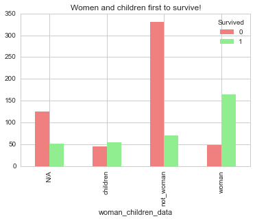

```python
%pylab inline
sns.set_style("whitegrid", {'axes.grid' : True})
df3[[0,1]].plot(kind='bar',color=['#F08080','#90EE90'],edgecolor = "none",title='Women and children first to survive!')
plt.show()
```

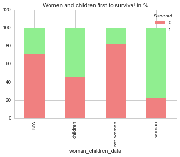

```python
%pylab inline
sns.set_style("whitegrid", {'axes.grid' : True})
df4 = this_df.groupby(['Survived', 'woman_children_data']).size().unstack('Survived').fillna(0)
df4 = df4.divide(df4.sum(axis=1),axis=0)*100
df4[[0,1]].plot(kind='bar', stacked=True,title='Women and children first to survive! in %', color=['#F08080','#90EE90'],edgecolor = "none")
#plt.show()
```

Now let's go back to those N/A passengers (No age provided in the data set). Their survival rate look similar to the adults male indeed.

```python
# A whole lot have ('Parch','SibSp') on a (0,0) value
this_df[this_df['woman_children_data']=='N/A'][['Age','Sex','Parch','SibSp']]
```

|  | Age | Sex | Parch | SibSp |
| --- | --- | --- | --- | --- |
| 5 | NaN | male | 0 | 0 |
| 17 | NaN | male | 0 | 0 |
| 19 | NaN | female | 0 | 0 |
| 26 | NaN | male | 0 | 0 |
| 28 | NaN | female | 0 | 0 |
| 29 | NaN | male | 0 | 0 |
| 31 | NaN | female | 0 | 1 |
| 32 | NaN | female | 0 | 0 |
| 36 | NaN | male | 0 | 0 |
| 42 | NaN | male | 0 | 0 |
| 45 | NaN | male | 0 | 0 |
| 46 | NaN | male | 0 | 1 |
| 47 | NaN | female | 0 | 0 |
| 48 | NaN | male | 0 | 2 |
| 55 | NaN | male | 0 | 0 |
| 64 | NaN | male | 0 | 0 |
| 65 | NaN | male | 1 | 1 |
| 76 | NaN | male | 0 | 0 |
| 77 | NaN | male | 0 | 0 |
| 82 | NaN | female | 0 | 0 |
| 87 | NaN | male | 0 | 0 |
| 95 | NaN | male | 0 | 0 |
| 101 | NaN | male | 0 | 0 |
| 107 | NaN | male | 0 | 0 |
| 109 | NaN | female | 0 | 1 |
| 121 | NaN | male | 0 | 0 |
| 126 | NaN | male | 0 | 0 |
| 128 | NaN | female | 1 | 1 |
| 140 | NaN | female | 2 | 0 |
| 154 | NaN | male | 0 | 0 |
| ... | ... | ... | ... | ... |
| 718 | NaN | male | 0 | 0 |
| 727 | NaN | female | 0 | 0 |
| 732 | NaN | male | 0 | 0 |
| 738 | NaN | male | 0 | 0 |
| 739 | NaN | male | 0 | 0 |
| 740 | NaN | male | 0 | 0 |
| 760 | NaN | male | 0 | 0 |
| 766 | NaN | male | 0 | 0 |
| 768 | NaN | male | 0 | 1 |
| 773 | NaN | male | 0 | 0 |
| 776 | NaN | male | 0 | 0 |
| 778 | NaN | male | 0 | 0 |
| 783 | NaN | male | 2 | 1 |
| 790 | NaN | male | 0 | 0 |
| 792 | NaN | female | 2 | 8 |
| 793 | NaN | male | 0 | 0 |
| 815 | NaN | male | 0 | 0 |
| 825 | NaN | male | 0 | 0 |
| 826 | NaN | male | 0 | 0 |
| 828 | NaN | male | 0 | 0 |
| 832 | NaN | male | 0 | 0 |
| 837 | NaN | male | 0 | 0 |
| 839 | NaN | male | 0 | 0 |
| 846 | NaN | male | 2 | 8 |
| 849 | NaN | female | 0 | 1 |
| 859 | NaN | male | 0 | 0 |
| 863 | NaN | female | 2 | 8 |
| 868 | NaN | male | 0 | 0 |
| 878 | NaN | male | 0 | 0 |
| 888 | NaN | female | 2 | 1 |

177 rows × 4 columns

```python
na_passenger_df = this_df[this_df['woman_children_data']=='N/A'][['Age','Sex','Parch','SibSp']]
na_passenger_w_0_Parch_0_SibSp_df = this_df[this_df['woman_children_data']=='N/A'][this_df['Parch']==0][this_df['SibSp']==0][['Age','Sex','Parch','SibSp']]
print "The proportion of N/A with ('Parch','SibSp') on a (0,0) value compared to all N/A is",round(float(len(na_passenger_w_0_Parch_0_SibSp_df))/len(na_passenger_df),2)
```

```
The proportion of N/A with ('Parch','SibSp') on a (0,0) value compared to all N/A is 0.75
```

Now lets investigage the **"NOT N/A with ('Parch','SibSp') on a (0,0)"** population

```python
not_na_passenger_w_0_Parch_0_SibSp_series = this_df[this_df['woman_children_data']!='N/A'][this_df['Parch']==0][this_df['SibSp']==0][['Age','Sex','Parch','SibSp','woman_children_data']].groupby(['woman_children_data']).size()
print not_na_passenger_w_0_Parch_0_SibSp_series
print ""
print "And in % "
print not_na_passenger_w_0_Parch_0_SibSp_series/not_na_passenger_w_0_Parch_0_SibSp_series.sum()
```

```
woman_children_data
children      16
not_woman    296
woman         92
dtype: int64

And in %
woman_children_data
children     0.039604
not_woman    0.732673
woman        0.227723
dtype: float64
```

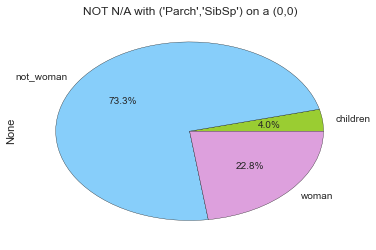

```python
#let's plot it out
%pylab inline
not_na_passenger_w_0_Parch_0_SibSp_series.plot(kind='pie',autopct='%1.1f%%',colors = ['yellowgreen', 'lightskyblue', 'plum'],title = "NOT N/A with ('Parch','SibSp') on a (0,0)")
plt.show()
```

Pie chart shows that ~75% of NOT N/A with ('Parch','SibSp') on a (0,0) are adult males. We've calculated that the proportion of N/A with ('Parch','SibSp') on a (0,0) value compared to all N/A is 75%

So if we assume the indenpendency of the 2 variables "being N/A (not age registred)" with "('Parch','SibSp') on a (0,0) value" we can safely infer that at least 75%*75% = ~56% of total N/A are males adult, wich start to explain why N/A passenger survive as adult males